# GShelorHomework5_lectures_12-13

Griffin Shelor  
14-3-2024

## Homework 5: Numpy and Matplotlib

```python
import numpy as np
import matplotlib.pyplot as plt
from netCDF4 import Dataset as netcdf_dataset

# adds in special scipy datasets
# !pip install pooch # for special datasets
from scipy import datasets
```

- Data courtesy of Introduction to Programming for Geoscientists, [Gerard J. Gorman (g.gorman@imperial.ac.uk)](http://www.imperial.ac.uk/people/g.gorman), [Nicolas Barral (n.barral@imperial.ac.uk)](http://www.imperial.ac.uk/people/n.barral)

### Q1. Loading the Dataset

- Load the data from "homework5_precipitation.csv" into a (2D) numpy `array`;
- Create two, 1D `numpy` arrays, one containing the years 1916-2016 and the other containg the months 1-12.
- Both of these arrays should have `dtype=int`;
- Print out the `shape` of (i) the data array loaded from the text file, (ii) the years array, and (iii) the months arrays.

Hint: if the length of your years array does not equal the number of rows in your data array, or the length of your months array does not equal the number of columns in your data array, you have done something wrong!

```python
## loading in array
precip = np.loadtxt('homework5_precipitation.csv', delimiter=',')
## creating years and month arrays
years = np.arange(1916, 2016.1, 1, dtype=int)
months = np.arange(1,12.1, 1, dtype=int)
## printing shape of arrays
print(precip.shape)
print(years.shape)
print(months.shape)
```

```
(101, 12)
(101,)
(12,)
```

### Q2. Write a nested `for` loop over all the rows (years) and columns (months) in your precipitation data array. Print the year, month, and precipitation value of all instances when precipitation values are > 170. Each printed line should have the year, month, and value when this condition is met.

```python
for row in range(len(years)):
    for colum in range(len(months)):
        ## checking to see if a given month's precipitation was above 170
        if precip[row,colum] > 170:
            ## printing year, month, and precipitation for that year and month if precipitation was above 170
            print(years[row], months[colum], precip[row,colum])
```

```
1929 11 175.6
1934 12 176.3
1940 11 203.0
1949 10 189.3
1970 11 186.4
1987 10 198.7
2000 10 185.9
2002 11 175.4
2009 11 177.3
2014 1 181.9
```

### Q3. Use `numpy` to calculate the mean and standard deviation of precipitation in each year. Make a plot with years on the x-axis and the mean precipitation in that year on the y-axis, with these calculated data points marked as red circles. Add error bars that correspond to the standard deviation in the precipitation values for each year. Label your plot axes.

Hint: recall that you can specify the "axis" when using `np.mean` and `np.std` on 2D arrays.

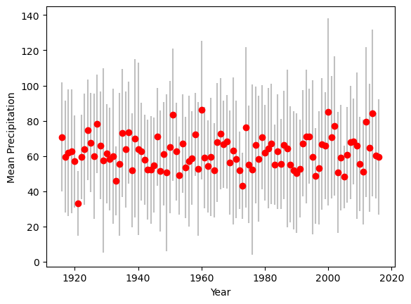

```python
## creating empty arrays for means and standard deviations to be appended to
precip_means = np.array([])
precip_stds = np.array([])
## calculating mean and SD for each year, appending to array
for i in range(len(years)):
    mean_p = precip[i,:].mean()
    std_p = precip[i,:].std()
    precip_means = np.append(precip_means, mean_p)
    precip_stds = np.append(precip_stds, std_p)

## plotting mean precip by year with error bars created using standard deviation
plt.errorbar(years, precip_means, yerr=precip_stds, fmt='or', ecolor='silver')
plt.xlabel("Year")
plt.ylabel("Mean Precipitation");
```

### Q4. Use `numpy` to calculate the total precipitation in each year. Print the year and the total precipitation in each of the five years with the lowest precipitation (five printed lines in total). Repeat this for the five years with the highest precipitation (again, five printed lines).

Hint: the function `np.argsort()` may be of use!

```python
## creating empty array to store sum of all monthly precip values for each year
precip_sums = np.array([])
## appending annual precipitation to precip_sums
for i in range(len(years)):
    sum_p = precip[i,:].sum()
    precip_sums = np.append(precip_means, mean_p)
## identifying indices with top 5 annual precip values
sorted_precip = np.argsort(precip_sums)
bottom5_precip = sorted_precip[0:5]
## printing bottom 5 annual precipitation values
print("Bottom 5 Precipitation Years")
for x in bottom5_precip:
    print("year:", years[x], "precipitation:",round(precip_sums[x], 3))

## printing top 5 annual precipitation values
print("Top 5 Precipitation Years")
top5_precip = sorted_precip[-6:-1]
for x in reversed(top5_precip):
    print("year:", years[x], "precipitation:",round(precip_sums[x], 3))
```

[output not shown]

### Q5. Did you know that image files can be treated as numpy `arrays`? In the cell below the code will load in an image and display it. Modify the code so that you "zoom in" and just display the face of the racoon. Save the zoomed image to a png file.

Hint: since `face` is an array, it can be sliced!

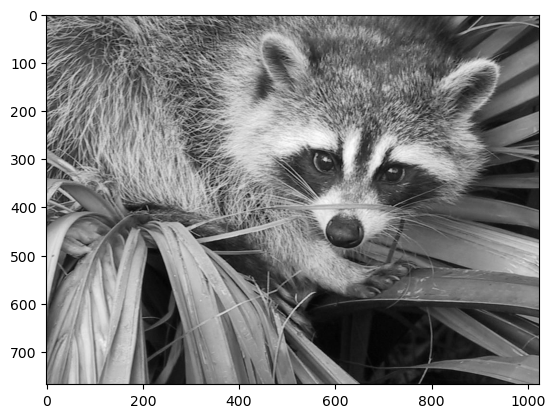

```python
# Edit this
face = datasets.face(gray=True)
plt.imshow(face, cmap=plt.cm.gray);
```

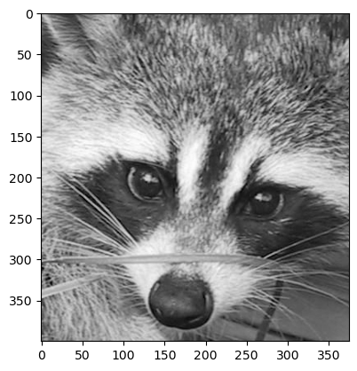

```python
## zooming in on just the face
face = datasets.face(gray=True)
face_zoom = face[100:500, 450:825]
plt.imshow(face_zoom, cmap=plt.cm.gray);

plt.savefig('zoomed_face.png')
```

### Q6. Working with the full image (i.e., not just the zoomed in face), change all the values that are less than 50 to a value of 50, and all values that are greater than or equal 100 to a value of 100. Plot the image.

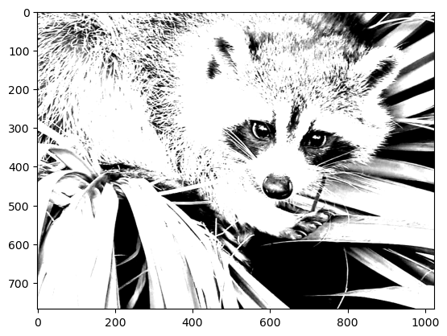

```python
## changing values below 50 to 50
face_edit1 = np.where(face < 50, 50, face)
## changing values above 100 to 100, keeping values from first
face_edit2 = np.where(face_edit1 > 100, 100, face_edit1)

## plotting fully edited image
plt.imshow(face_edit2, cmap=plt.cm.gray);
```

### Q7. Plotting a topographic grid.

1. Download a topographic grid in netcdf format from https://www.gmrt.org/GMRTMapTool/ with the following lon/lat limits: xlim=(-116.5, -114.5) for longitudes, ylim=(39.4, 41.3) for latitudes.
2. After selecting these limits, press the "Create Grid File" button. When making your grid choose the following options: "Coards/CF Compliant NetCDF" format, "Unmasked", and "Medium" resolution.
3. Load the data using the `netcdf_dataset` command and make three numpy `arrays` from the `lon`, `lat`, and `altitude` fields.
4. Plot the grid using `plt.imshow` with the `'terrain'` colormap. Be sure to label the x and y axes, which should have units of longitude (degrees) and latitude (degrees). Save the image to a png file.

**Hint**: At the same website you downloaded the .grd file, you can also display an image of the topography. This may help you check the plot you make below.

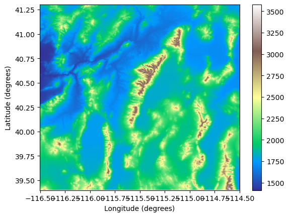

```python
# Import the data
topo_grid = netcdf_dataset('Homework5_topo.grd')

## check variable names
topo_grid.variables.keys()

# Extract the grid variables into numpy arrays
x_topo = np.asarray(topo_grid.variables['lon'])
y_topo = np.asarray(topo_grid.variables['lat'])
alt_topo = np.asarray(topo_grid.variables['altitude'])

# determine extent of of the data
xmin = np.min(x_topo)
xmax = np.max(x_topo)
ymin = np.min(y_topo)
ymax = np.max(y_topo)

## plotting elevation
plt.imshow(alt_topo, cmap='terrain', origin = 'lower',aspect = 'auto',extent = [xmin, xmax, ymin, ymax])
plt.xlabel("Longitude (degrees)")
plt.ylabel("Latitude (degrees)")
plt.colorbar();

## saving figure
plt.savefig('altitude.png')
```

### Please list any other students that you worked with on this assignment

```python
# I worked with the following students: Hannah Potts, Faith Machuca
```

### To receive credit for this homework upload both the .ipynb file and an .html version.